# 12_1_Benchmarks_Forecasts_Decomposition

Juan Garbayo

3/3/2022

# References

1. Hyndman, R.J., & Athanasopoulos, G., 2021. *Forecasting: principles and practice*. 3rd edition.
2. Fable package documentation
- https://fable.tidyverts.org/index.html
- https://fable.tidyverts.org/articles/fable.html

# Packages

```r
library(fpp3)
```

In this session we are going to:

- Explore some benchmark methods
- Practice the basic steps behind fitting models and forecasting with the library `fable`
- Do some exercises

# Benchmark methods

In session 9 (asynchronous) we worked with two different benchmark methods: the naïve and the mean method. We are now going to introduce some more benchmark methods.

For the most simple examples we will be working with this dataset:

```r
bricks <- aus_production %>%
  filter_index("1970 Q1" ~ "2004 Q4") %>%
  select(Bricks)

head(bricks)
```

```
## # A tsibble: 6 x 2 [1Q]
##   Bricks Quarter
##    <dbl>   <qtr>
## 1    386 1970 Q1
## 2    428 1970 Q2
## 3    434 1970 Q3
## 4    417 1970 Q4
## 5    385 1971 Q1
## 6    433 1971 Q2
```

## Mean method

Forecasts of all future values are equal to the average of the historical data.

$$\hat{y}_{T+h|T} = \bar{y} = (y_{1}+\dots+y_{T})/T.$$

- NOTE: $\hat{y}_{T+h|T}$ means estimate of $y_{T+h}$ based on data $y_1,\dots,y_T$

### Defining and training the model (generating the fitted values or *estimates*):

```r
fit <- bricks %>% model(mean = MEAN(Bricks))
fit
```

```
## # A mable: 1 x 1
##      mean
##   <model>
## 1  <MEAN>
```

This particular mable (model table) has 1 row (1 time series fitted) and 1 column (1 model)

### Extracting and depicting the fitted values:

```r
fitted_vals <- fit %>% augment()
head(fitted_vals)
```

```
## # A tsibble: 6 x 6 [1Q]
## # Key:       .model [1]
##   .model Quarter Bricks .fitted .resid .innov
##   <chr>    <qtr>  <dbl>   <dbl>  <dbl>  <dbl>
## 1 mean   1970 Q1    386    451.  -64.9  -64.9
## 2 mean   1970 Q2    428    451.  -22.9  -22.9
## 3 mean   1970 Q3    434    451.  -16.9  -16.9
## 4 mean   1970 Q4    417    451.  -33.9  -33.9
## 5 mean   1971 Q1    385    451.  -65.9  -65.9
## 6 mean   1971 Q2    433    451.  -17.9  -17.9
```

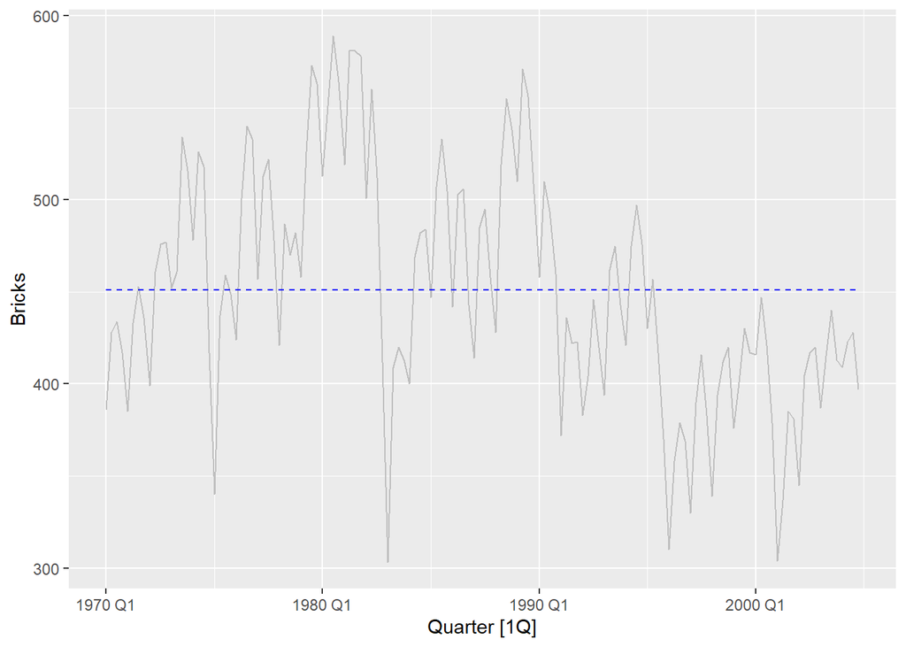

```r
fitted_vals %>%
  filter(.model == "mean") %>%
  autoplot(Bricks, colour = "gray") +
  geom_line(aes(y=.fitted), colour = "blue", linetype = "dashed")
```

### Generating and printing forecasts:

```r
# produce forecasts for 8 timesteps
forecasts <- fit %>% forecast(h = 8)
forecasts
```

```
## # A fable: 8 x 4 [1Q]
## # Key:     .model [1]
##   .model Quarter       Bricks .mean
##   <chr>    <qtr>       <dist> <dbl>
## 1 mean   2005 Q1 N(451, 4022)  451.
## 2 mean   2005 Q2 N(451, 4022)  451.
## 3 mean   2005 Q3 N(451, 4022)  451.
## 4 mean   2005 Q4 N(451, 4022)  451.
## 5 mean   2006 Q1 N(451, 4022)  451.
## 6 mean   2006 Q2 N(451, 4022)  451.
## 7 mean   2006 Q3 N(451, 4022)  451.
## 8 mean   2006 Q4 N(451, 4022)  451.
```

The output is a so called **fable** (forecast table). In fact, the forecast is being generated using the package `fable`

**Important**: to depict the forecasts along with the series use **autoplot with the forecasts as the first argument**.

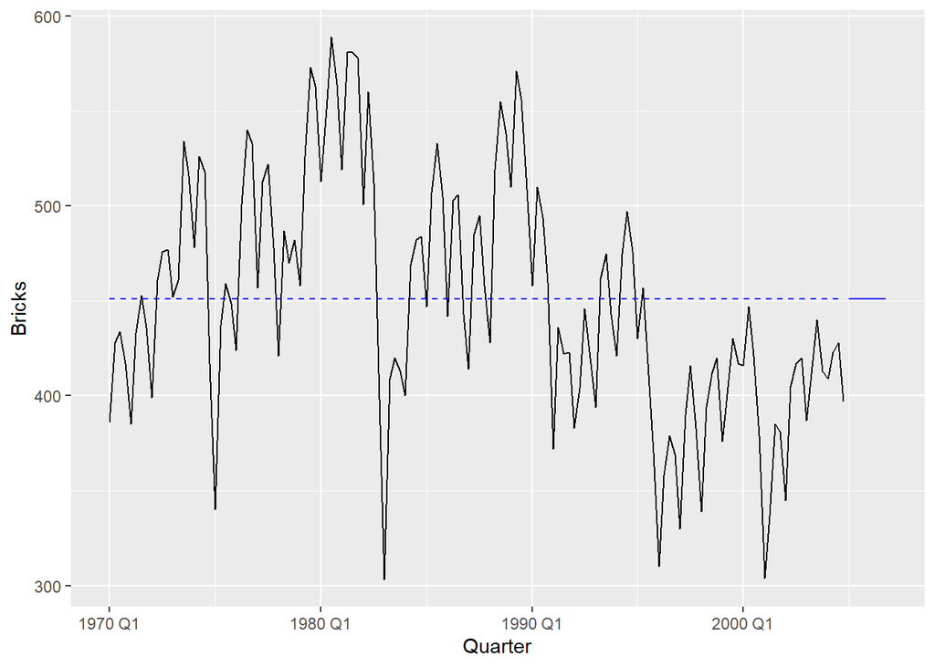

```r
# TO depict the forecasts and the original series use autoplot() with the
autoplot(forecasts, bricks, level = FALSE) +
autolayer(fitted_vals, .fitted, colour = "blue", linetype = "dashed") #adds the fitted values - optional
```

Alternatively, using the pipe:

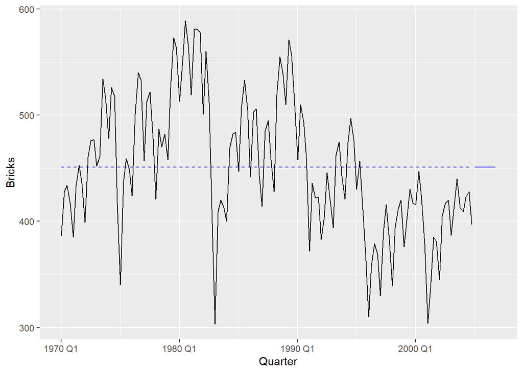

```r
# Depict the forecasts
forecasts %>%
  autoplot(bricks, level = FALSE) +
  autolayer(fitted_vals, .fitted, colour = "blue", linetype = "dashed")
```

## Naïve

All forecasts to be the value of the last observation.

We are going to do a forecast on the aus_exports dataset

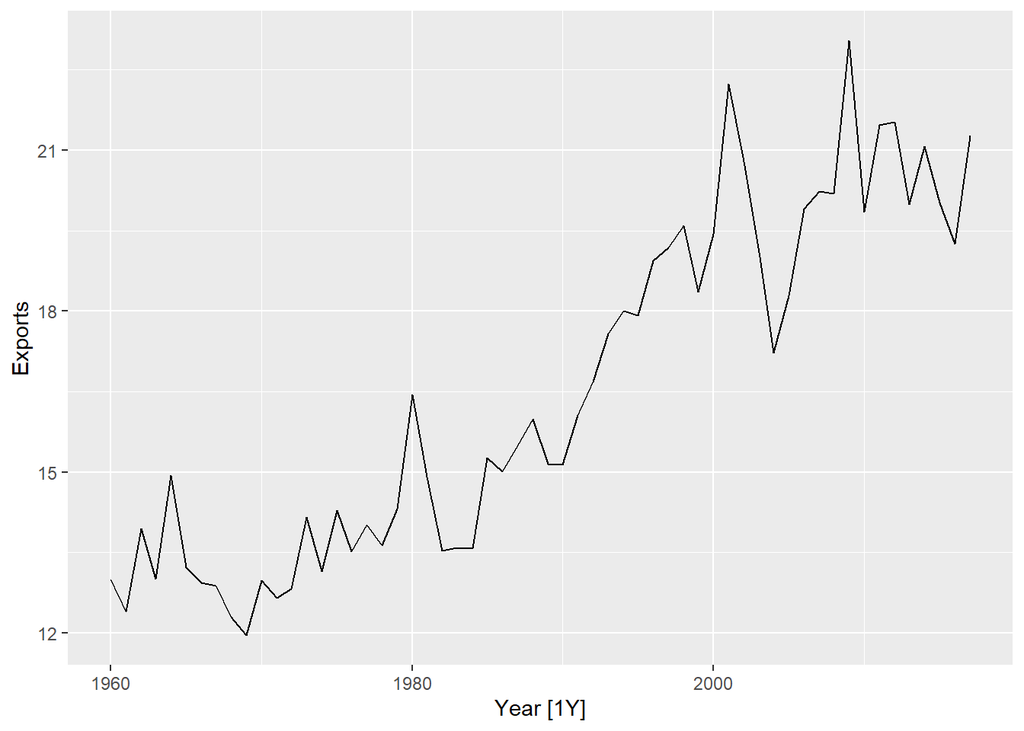

```r
aus_exports <- filter(global_economy, Country == "Australia")

autoplot(aus_exports, Exports)
```

### Defining and training the model (generating the fitted values or *estimates*):

```r
fit <- aus_exports %>% model(Naive = NAIVE(Exports))
fit
```

```
## # A mable: 1 x 2
## # Key:     Country [1]
##   Country     Naive
##   <fct>     <model>
## 1 Australia <NAIVE>
```

### Extracting and depicting the fitted values:

```r
# Extract fitted values and inspect table
fitted_vals <- fit %>% augment()
head(fitted_vals)
```

```
## # A tsibble: 6 x 7 [1Y]
## # Key:       Country, .model [1]
##   Country   .model  Year Exports .fitted .resid .innov
##   <fct>     <chr>  <dbl>   <dbl>   <dbl>  <dbl>  <dbl>
## 1 Australia Naive   1960    13.0    NA   NA     NA
## 2 Australia Naive   1961    12.4    13.0 -0.591 -0.591
## 3 Australia Naive   1962    13.9    12.4  1.54   1.54
## 4 Australia Naive   1963    13.0    13.9 -0.937 -0.937
## 5 Australia Naive   1964    14.9    13.0  1.93   1.93
## 6 Australia Naive   1965    13.2    14.9 -1.72  -1.72
```

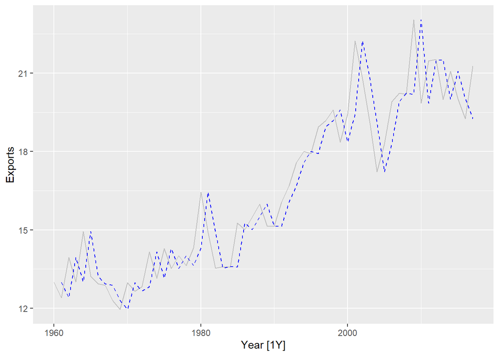

```r
# Print fitted values along with the original series
fitted_vals %>%
  filter(.model == "Naive") %>%
  autoplot(Exports, colour = "gray") +
  geom_line(aes(y=.fitted), colour = "blue", linetype = "dashed")
```

### Generating and printing forecasts:

```r
# produce forecasts for 8 timesteps
forecasts <- fit %>% forecast(h = 8)
forecasts
```

```
## # A fable: 8 x 5 [1Y]
## # Key:     Country, .model [1]
##   Country   .model  Year    Exports .mean
##   <fct>     <chr>  <dbl>     <dist> <dbl>
## 1 Australia Naive   2018 N(21, 1.5)  21.3
## 2 Australia Naive   2019 N(21, 3.1)  21.3
## 3 Australia Naive   2020 N(21, 4.6)  21.3
## 4 Australia Naive   2021 N(21, 6.1)  21.3
## 5 Australia Naive   2022 N(21, 7.6)  21.3
## 6 Australia Naive   2023 N(21, 9.2)  21.3
## 7 Australia Naive   2024  N(21, 11)  21.3
## 8 Australia Naive   2025  N(21, 12)  21.3
```

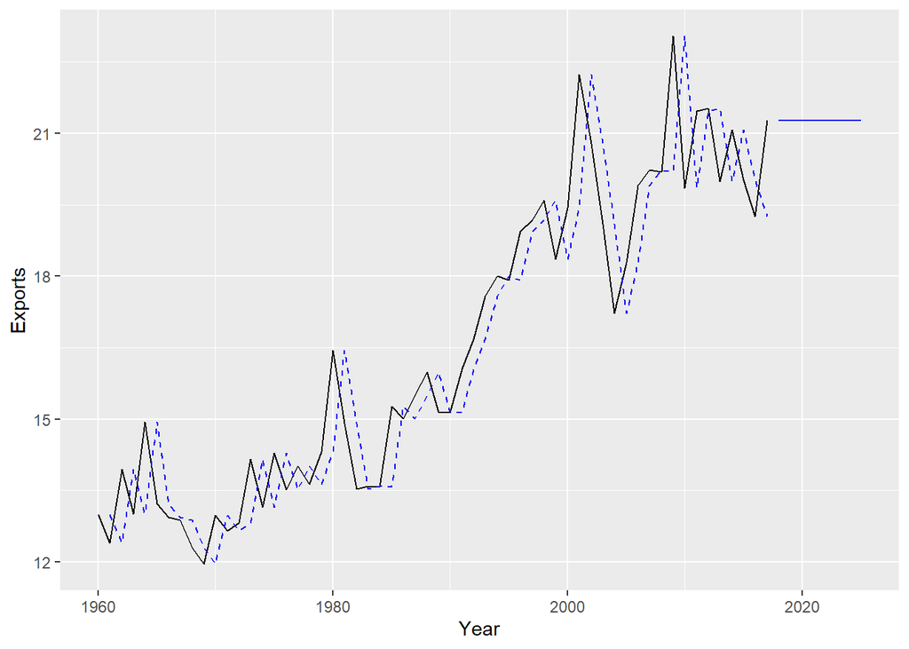

```r
# Depict the forecasts
forecasts %>%
  autoplot(aus_exports, level = FALSE) +
  autolayer(fitted_vals, .fitted, colour = "blue", linetype = "dashed")
```

## Seasonal Naive Method

Each forecast equal to the last observed value from the same season (e.g. the same month of the previous year). Formally the *forecast at time T+h*:

$$\hat{y}_{T+h|T} = y_{T+h-m(k+1)}$$

where:

- $m$ is the seasonal period
- $k$ is the integer part of (h-1)/m (i.e, the number of complete years in the forecast period prior to time T + h)

The formula above looks more complicated than it actually is.

- **Example with monthly data**: all future February values will be equal to the last observed February value

Let us du an example with the us_employment series:

```r
employed <- filter(us_employment, Title == "Total Private", Month >= yearmonth("01-01-2010"))
head(employed)
```

```
## # A tsibble: 6 x 4 [1M]
## # Key:       Series_ID [1]
##      Month Series_ID     Title         Employed
##      <mth> <chr>         <chr>            <dbl>
## 1 2010 Jan CEU0500000001 Total Private   105444
## 2 2010 Feb CEU0500000001 Total Private   105490
## 3 2010 Mar CEU0500000001 Total Private   106176
## 4 2010 Apr CEU0500000001 Total Private   107220
## 5 2010 May CEU0500000001 Total Private   107931
## 6 2010 Jun CEU0500000001 Total Private   108710
```

```
## Plot variable not specified, automatically selected `.vars = Employed`
```

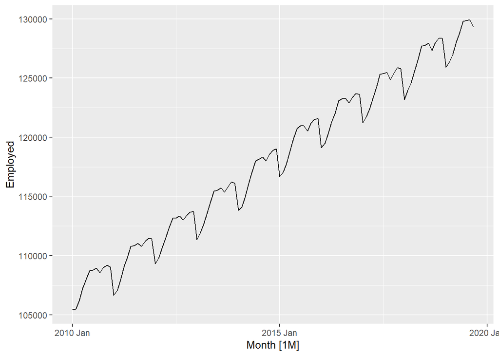

```r
autoplot(employed)
```

### Defining and training the model (generating the fitted values or *estimates*)

**NOTE**: within the special function `lag()` we need to specify the length of the seasonality to be considered

```r
fit <- employed %>% model(SNaive = SNAIVE(Employed ~ lag("year")))
fit
```

```
## # A mable: 1 x 2
## # Key:     Series_ID [1]
##   Series_ID       SNaive
##   <chr>          <model>
## 1 CEU0500000001 <SNAIVE>
```

### Extracting and depicting the fitted values:

```r
# Extract fitted values and inspect table
fitted_vals <- fit %>% augment()
head(fitted_vals)
```

```
## # A tsibble: 6 x 7 [1M]
## # Key:       Series_ID, .model [1]
##   Series_ID     .model    Month Employed .fitted .resid .innov
##   <chr>         <chr>     <mth>    <dbl>   <dbl>  <dbl>  <dbl>
## 1 CEU0500000001 SNaive 2010 Jan   105444      NA     NA     NA
## 2 CEU0500000001 SNaive 2010 Feb   105490      NA     NA     NA
## 3 CEU0500000001 SNaive 2010 Mar   106176      NA     NA     NA
## 4 CEU0500000001 SNaive 2010 Apr   107220      NA     NA     NA
## 5 CEU0500000001 SNaive 2010 May   107931      NA     NA     NA
## 6 CEU0500000001 SNaive 2010 Jun   108710      NA     NA     NA
```

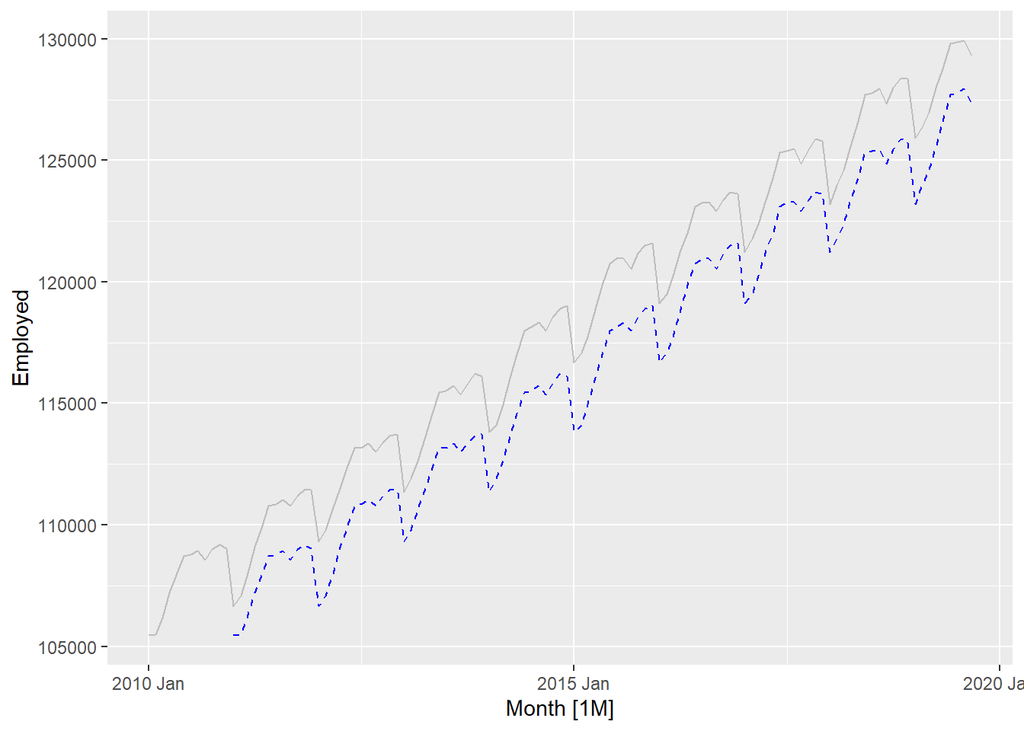

```r
# Print fitted values along with the original series
fitted_vals %>%
  filter(.model == "SNaive") %>%
  autoplot(Employed, colour = "gray") +
  geom_line(aes(y=.fitted), colour = "blue", linetype = "dashed")
```

### Generating and printing forecasts:

```r
# produce forecasts for 8 timesteps
forecasts <- fit %>% forecast(h = 36)
forecasts
```

```
## # A fable: 36 x 5 [1M]
## # Key:     Series_ID, .model [1]
##    Series_ID     .model    Month           Employed  .mean
##    <chr>         <chr>     <mth>             <dist>  <dbl>
##  1 CEU0500000001 SNaive 2019 Oct N(128001, 5538565) 128001
##  2 CEU0500000001 SNaive 2019 Nov N(128415, 5538565) 128415
##  3 CEU0500000001 SNaive 2019 Dec N(128363, 5538565) 128363
##  4 CEU0500000001 SNaive 2020 Jan N(125932, 5538565) 125932
##  5 CEU0500000001 SNaive 2020 Feb N(126370, 5538565) 126370
##  6 CEU0500000001 SNaive 2020 Mar N(126994, 5538565) 126994
##  7 CEU0500000001 SNaive 2020 Apr N(128007, 5538565) 128007
##  8 CEU0500000001 SNaive 2020 May N(128771, 5538565) 128771
##  9 CEU0500000001 SNaive 2020 Jun N(129800, 5538565) 129800
## 10 CEU0500000001 SNaive 2020 Jul N(129883, 5538565) 129883
## # ... with 26 more rows
```

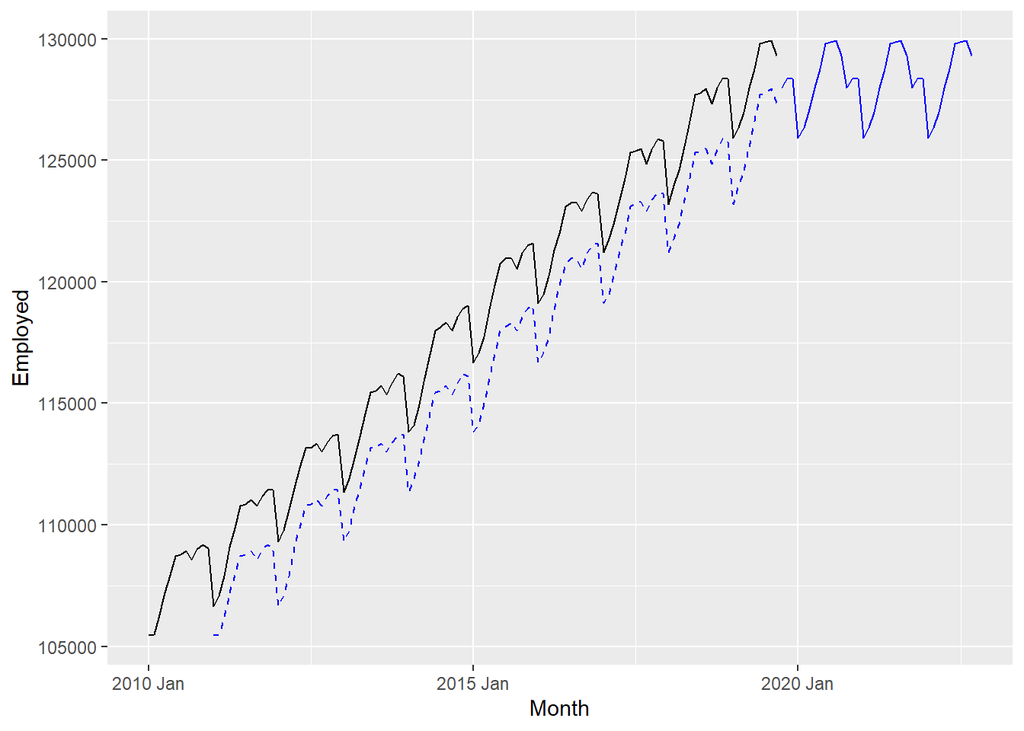

```r
# Depict the forecasts
forecasts %>%
  autoplot(employed, level = FALSE) +
  autolayer(fitted_vals, .fitted, colour = "blue", linetype = "dashed")
```

## Drift Method

Variation of the naïve method. Allows forecasts to increase or decrease over time. **Drift** is the amount of change over time, set to be the **average change in the historical data**:

$$\hat{y}_{T+h|T} = y_{T} + \frac{h}{T-1}\sum_{t=2}^T (y_{t}-y_{t-1}) = y_{T} + h \left( \frac{y_{T} -y_{1}}{T-1}\right).$$

**Equivalent to drawing a line between the first and last observations and extrapolating into the future** (the final graph of the example clarifies this further).

### Defining and training the model (generating the fitted values or *estimates*)

```r
fit <- employed %>% model(Drift = RW(Employed ~ drift()))
fit
```

```
## # A mable: 1 x 2
## # Key:     Series_ID [1]
##   Series_ID             Drift
##   <chr>               <model>
## 1 CEU0500000001 <RW w/ drift>
```

### Extracting and depicting the fitted values

```r
# Extract fitted values and inspect table
fitted_vals <- fit %>% augment()
head(fitted_vals)
```

```
## # A tsibble: 6 x 7 [1M]
## # Key:       Series_ID, .model [1]
##   Series_ID     .model    Month Employed .fitted .resid .innov
##   <chr>         <chr>     <mth>    <dbl>   <dbl>  <dbl>  <dbl>
## 1 CEU0500000001 Drift  2010 Jan   105444     NA     NA     NA
## 2 CEU0500000001 Drift  2010 Feb   105490 105650.  -160.  -160.
## 3 CEU0500000001 Drift  2010 Mar   106176 105696.   480.   480.
## 4 CEU0500000001 Drift  2010 Apr   107220 106382.   838.   838.
## 5 CEU0500000001 Drift  2010 May   107931 107426.   505.   505.
## 6 CEU0500000001 Drift  2010 Jun   108710 108137.   573.   573.
```

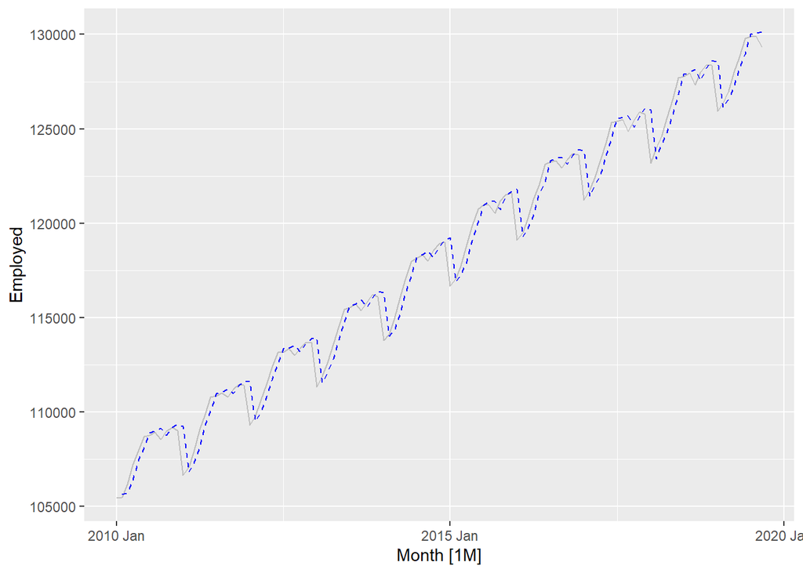

```r
# Print fitted values along with the original series
fitted_vals %>%
  filter(.model == "Drift") %>%
  autoplot(Employed, colour = "gray") +
  geom_line(aes(y=.fitted), colour = "blue", linetype = "dashed")
```

### Generating and printing the forecast

```r
# produce forecasts for 36 timesteps
forecasts <- fit %>% forecast(h = 36)
forecasts
```

```
## # A fable: 36 x 5 [1M]
## # Key:     Series_ID, .model [1]
##    Series_ID     .model    Month           Employed   .mean
##    <chr>         <chr>     <mth>             <dist>   <dbl>
##  1 CEU0500000001 Drift  2019 Oct  N(129518, 758249) 129518.
##  2 CEU0500000001 Drift  2019 Nov N(129724, 1529572) 129724.
##  3 CEU0500000001 Drift  2019 Dec N(129929, 2313968) 129929.
##  4 CEU0500000001 Drift  2020 Jan N(130135, 3111437) 130135.
##  5 CEU0500000001 Drift  2020 Feb N(130341, 3921980) 130341.
##  6 CEU0500000001 Drift  2020 Mar N(130547, 4745596) 130547.
##  7 CEU0500000001 Drift  2020 Apr N(130752, 5582285) 130752.
##  8 CEU0500000001 Drift  2020 May N(130958, 6432047) 130958.
##  9 CEU0500000001 Drift  2020 Jun N(131164, 7294883) 131164.
## 10 CEU0500000001 Drift  2020 Jul N(131370, 8170792) 131370.
## # ... with 26 more rows
```

```r
# Extract the initial and final points of the series
# to depict the average change slope.
n_rows = nrow(employed)
drift_points <- tibble(Month = c(employed$Month[1], employed$Month[n_rows]),
                       Employed = c(employed$Employed[1], employed$Employed[n_rows])) %>%
                as_tsibble()
```

```
## Using `Month` as index variable.
```

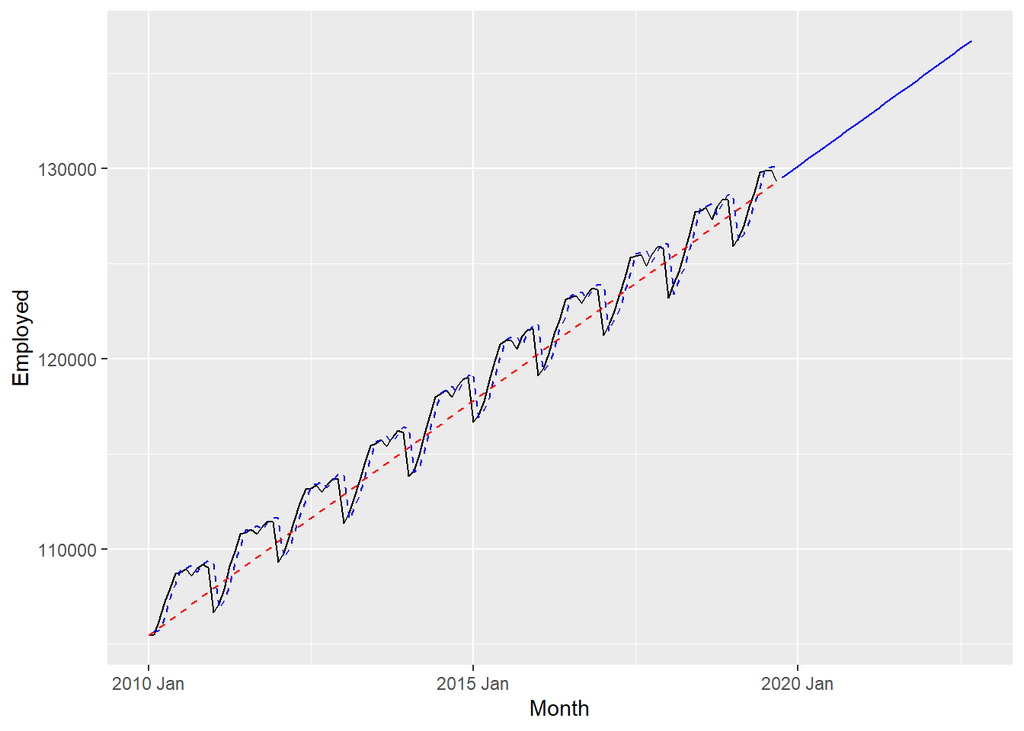

```r
# Depict the forecasts
forecasts %>%
  autoplot(employed, level = FALSE) +
  autolayer(fitted_vals, .fitted, colour = "blue", linetype = "dashed") +
  geom_line(drift_points, mapping = aes(x = Month, y = Employed), color = "red", linetype = "dashed")
```

In the above graph we can see that:

1. The forecasts are generated following the slope of the line that connects the initial and final points of the series (red slope). A further example is depicted in the image below:

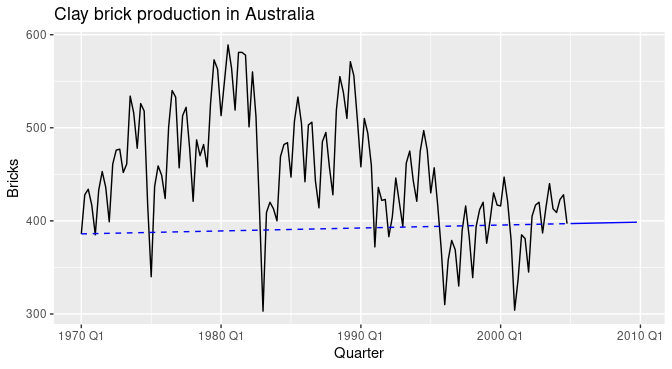

Figure 1: Further example of the drift method. From [1]

# Forecasting with decomposition:

Let:

- $\hat{A_t}$ be the seasonally adjusted component of a time series
- $\hat{S_t}$ be the seasonal component of a time series

The decomposed series can be written as:

- $y_t = \hat{S}_t + \hat{A}_t$ for additive schemes
  - where $\hat{A}_t = \hat{T}_t+\hat{R}_{t}$ is the seasonally adjusted component.
- $y_t = \hat{S}_t\hat{A}_t$ for multiplicative schemes
  - where $\hat{A}_t = \hat{T}_t\hat{R}_{t}$ is the seasonally adjusted component.

To forecast a decomposed time series $\hat{S_t}$ and $\hat{A_t}$ are forecast separately:

- $\hat{A_t}$: any non-seasonal forecasting method may be used (drift method, holt’s method, ARIMA)…
- $\hat{S_t}$: usually assumed to remain unchanged, or changing very slowly. It is usually forecast by taking the latest observed seasonal Naïve.

## Forecasting the seasonally adjust component:

Let us produce a forecast of the seasonally adjusted series `employed` used earlier in this notebook:

```r
employed <- filter(us_employment, Title == "Total Private", Month >= yearmonth("01-01-2010"))
head(employed)
```

```
## # A tsibble: 6 x 4 [1M]
## # Key:       Series_ID [1]
##      Month Series_ID     Title         Employed
##      <mth> <chr>         <chr>            <dbl>
## 1 2010 Jan CEU0500000001 Total Private   105444
## 2 2010 Feb CEU0500000001 Total Private   105490
## 3 2010 Mar CEU0500000001 Total Private   106176
## 4 2010 Apr CEU0500000001 Total Private   107220
## 5 2010 May CEU0500000001 Total Private   107931
## 6 2010 Jun CEU0500000001 Total Private   108710
```

```
## Plot variable not specified, automatically selected `.vars = Employed`
```

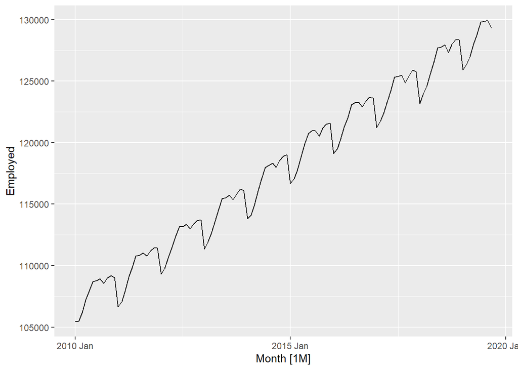

```r
autoplot(employed)
```

### Obtain the seasonally adjusted component

```r
dcmp <- employed %>%
  model(STL(Employed)) %>%
  components()

head(dcmp)
```

```
## # A dable: 6 x 8 [1M]
## # Key:     Series_ID, .model [1]
## # :        Employed = trend + season_year + remainder
##   Series_ID  .model    Month Employed  trend season_year remainder season_adjust
##   <chr>      <chr>     <mth>    <dbl>  <dbl>       <dbl>     <dbl>         <dbl>
## 1 CEU050000~ STL(E~ 2010 Jan   105444 1.07e5      -2016.    272.         107460.
## 2 CEU050000~ STL(E~ 2010 Feb   105490 1.07e5      -1816.     -8.49       107306.
## 3 CEU050000~ STL(E~ 2010 Mar   106176 1.07e5      -1231.    -33.0        107407.
## 4 CEU050000~ STL(E~ 2010 Apr   107220 1.08e5       -361.     14.7        107581.
## 5 CEU050000~ STL(E~ 2010 May   107931 1.08e5        305.    -69.4        107626.
## 6 CEU050000~ STL(E~ 2010 Jun   108710 1.08e5       1006.   -121.         107704.
```

```
## Plot variable not specified, automatically selected `.vars = season_adjust`
```

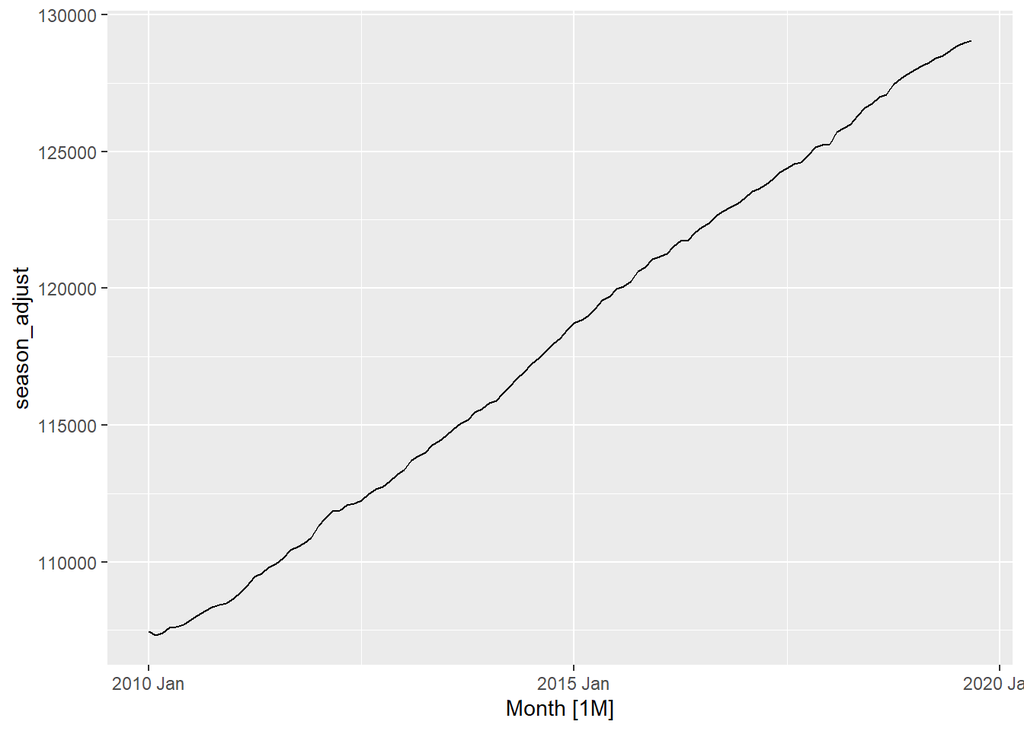

```r
season_adjust <- dcmp %>% select(season_adjust)
season_adjust %>% autoplot()
```

### Fit the model

```r
# Fit the model
fit <- season_adjust %>%
          model(Drift = RW(season_adjust ~ drift()))

fit
```

```
## # A mable: 1 x 1
##           Drift
##         <model>
## 1 <RW w/ drift>
```

### Generate the forecasts

predict 36 timesteps

```r
forecasts <- fit %>% forecast(h = 36)
head(forecasts)
```

```
## # A fable: 6 x 4 [1M]
## # Key:     .model [1]
##   .model    Month    season_adjust   .mean
##   <chr>     <mth>           <dist>   <dbl>
## 1 Drift  2019 Oct  N(129232, 8699) 129232.
## 2 Drift  2019 Nov N(129418, 17548) 129418.
## 3 Drift  2019 Dec N(129604, 26546) 129604.
## 4 Drift  2020 Jan N(129790, 35695) 129790.
## 5 Drift  2020 Feb N(129976, 44994) 129976.
## 6 Drift  2020 Mar N(130162, 54443) 130162.
```

### Depict the forecasts together with the seasonally adjusted series:

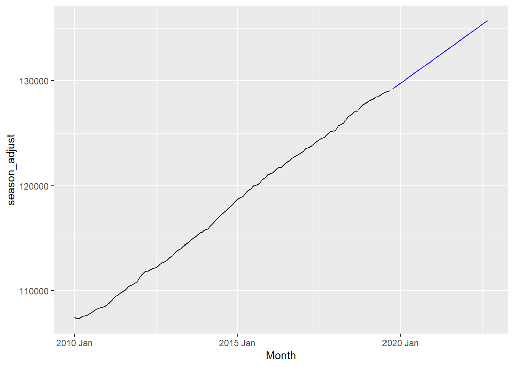

```r
forecasts %>% autoplot(season_adjust, level = FALSE)
```